# Directrices de Gestión Ambiental

Principales indicadores para caracterizar las organizaciones distinguidas por el programa de Directrices de Gestión Ambiental del Sistema Argentino de Calidad Turística.

El cambio climático es uno de los desafíos más urgentes que enfrenta la humanidad. De acuerdo con el [Grupo Intergubernamental de Expertos sobre el Cambio Climático (IPCC)](https://www.ipcc.ch/report/ar6/wg2/downloads/report/IPCC_AR6_WGII_FullReport.pdf), se espera que, en las próximas décadas, el incremento de la temperatura media mundial por encima de los 1,5ºC con respecto a los niveles preindustriales, lleve al aumento en la periodicidad e intensidad de los fenómenos climáticos extremos, acarreando grandes consecuencias para toda la sociedad y, particularmente, para los sectores más vulnerables de la misma.

En este marco y en función del principio 3 de la Ley Nacional de Turismo 25.997, el cual consagra al desarrollo sustentable como una de las guías rectoras para el fomento, el desarrollo, la promoción y la regulación de la actividad turística, el **Ministerio de Turismo y Deportes de la Nación (MINTURyDEP)**, a través de la **Subsecretaría de Calidad, Accesibilidad y Sustentabilidad del Turismo Nacional** y la **Dirección Nacional de Calidad e Innovación Turística**, implementa el programa de **Directrices de Gestión Ambiental (DGA)** perteneciente al [**Sistema Argentino de Calidad Turística (SACT)**](https://www.argentina.gob.ar/turismo/sistema-argentino-de-calidad-turistica/programas).

Las DGA tienen por objetivo garantizar la calidad ambiental, social y cultural de las organizaciones turísticas a través de la difusión de un conjunto de recomendaciones capaces de guiar a dichas entidades hacia el establecimiento de un sistema de gestión ambiental, que contribuya a la calidad de servicio, solucione y atenúe los impactos producidos y minimice los costos de gestión y adaptación. En este sentido, la implementación de estas directrices en una localidad apunta a producir un impacto global y busca instalar una gestión ambiental integrada del destino, involucrando a los sectores público y privado, en la medida de que ello sea posible.

Hasta el momento, **395 DGA fueron otorgadas** a diversas organizaciones del país desde el año 2013. Actualmente, el **rubro** con el mayor número de organizaciones distinguidas por este subprograma es el de **alojamientos**, con **202 casos**, el **51% del total**.

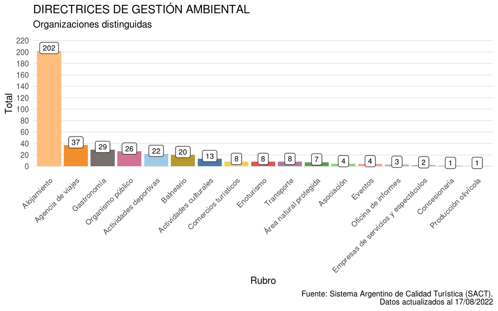

De aquellas 202 organizaciones pertenecientes al rubro de alojamientos, la mayoría son **hoteles (72)** y **cabañas (43)**. Juntas, ambas categorías hacen al **29% del total de las organizaciones distinguidas por el subprograma**.

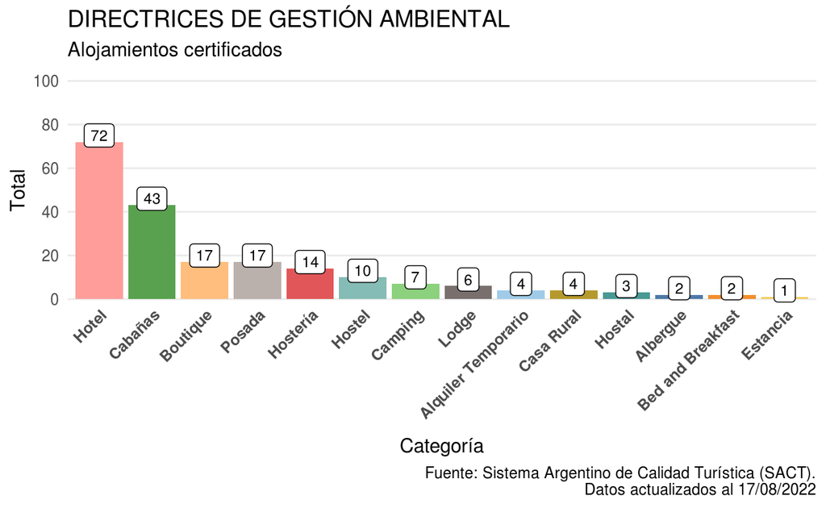

Con respecto a la distibución espacial de las organizaciones distinguidas por mencionado subprograma, la mayoría se ubica en la **Ciudad Autónoma de Buenos Aires (62)** y, en un escalón por debajo, en las provincias de **Misiones (48), Jujuy (40) y Chubut (40)**. Sin embargo, siete provincias argentinas todavía no cuentan con organizaciones distinguidas y cinco lo hacen con menos de 10.

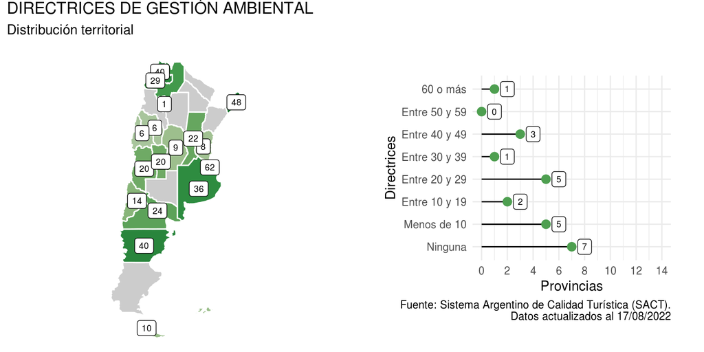

Al hacer foco en las ciuades del país, la **Ciudad Autónoma de Buenos Aires** es la **urbe con el mayor número de organizaciones distinguidas con las Directrices de Gestión Ambiental, con 62 casos**. Luego, el podio lo completan las ciudades de **Mar del Plata (Buenos Aires), Salta (Salta) y San Carlos de Bariloche (Río Negro) con 19 cada una**.

**CIUDADES CON MÁS ORGANIZACIONES DISTINGUIDAS CON LAS DIRECTRICES DE GESTIÓN AMBIENTAL**

TOP 10

| **Ciudad** | **Provincia** | **Organizaciones Distinguidas** | **% sobre el total provincial** |
| --- | --- | --- | --- |
| Ciudad Autónoma de Buenos Aires | Ciudad Autónoma de Buenos Aires | 62 | 100,0% |
| Mar del Plata | Buenos Aires | 19 | 52,8% |
| Salta | Salta | 19 | 65,5% |
| San Carlos de Bariloche | Río Negro | 19 | 79,2% |
| Tilcara | Jujuy | 15 | 37,5% |
| Esquel | Chubut | 14 | 35,0% |
| Purmamarca | Jujuy | 12 | 30,0% |
| Maipú | Mendoza | 11 | 55,0% |
| Reconquista | Santa Fe | 11 | 50,0% |
| Puerto Madryn | Chubut | 10 | 25,0% |

**Fuente:** Sistema Argentino de Calidad Turística (SACT). Datos actualizados al 17/08/2022

## Recursos

[**Informe** (disponible en la Biblioteca)](https://biblioteca.yvera.tur.ar/)

[**Datos Abiertos**](https://datos.yvera.gob.ar/dataset/organizaciones-distinguidas-sistema-argentino-calidad-turistica-sact)